# Religie na świecie

## Biblioteki i używane funkcje

### Użyte biblioteki:

- kableExtra
- dplyr
- stringi
- ggplot2
- readr
- reshape2
- grid
- lubridate

### Użyte funkcje:

- [xml2csv](https://www.gagolewski.com/resources/data/travel_stackexchange_com/readme.txt) by Marek Gągolewski
- [multiplot](https://stackoverflow.com/questions/24387376/r-error-could-not-find-function-multiplot-using-cookbook-example) z forum StackOverflow

## Liczba postów na dzień

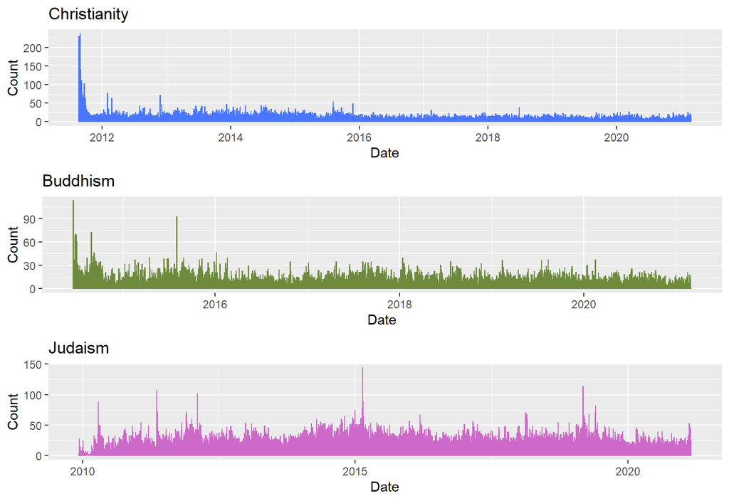

## Najwięcej postów jednego dnia

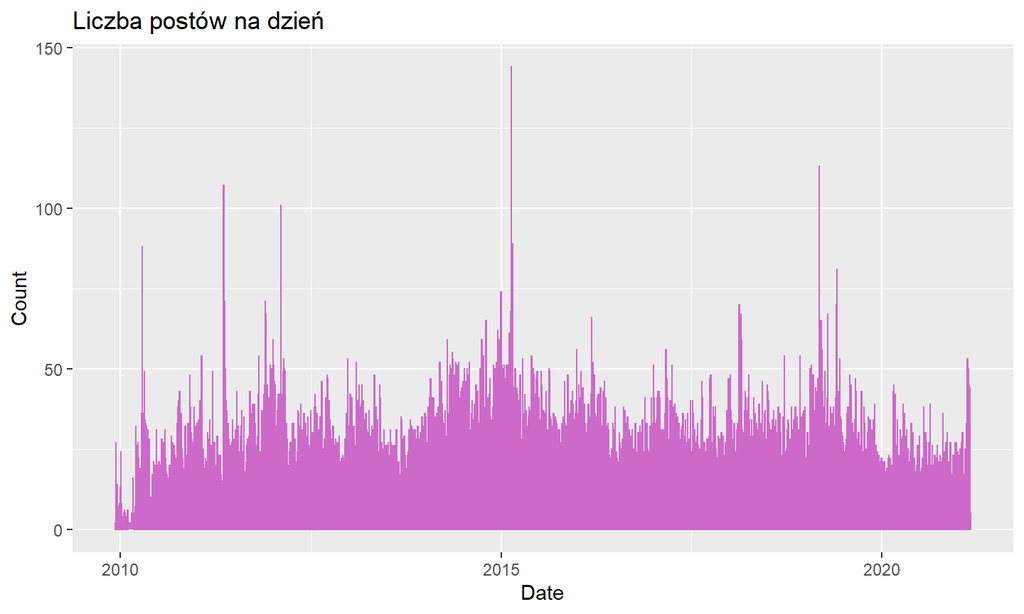

| Date | Number of Posts |
| --- | --- |
| 2015-02-19 | 144 |

## Znalezione artykuły

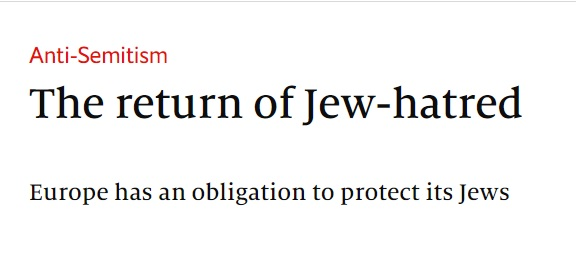

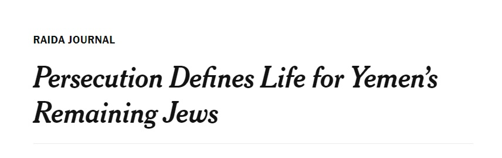

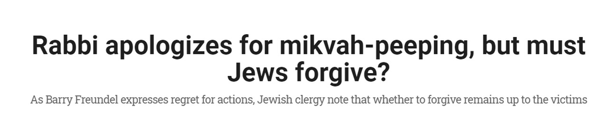

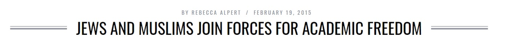

## Treści postów z 19.02.2015

| Title |
| --- |
| What does Judaism think of math? |
| PTIJ: If a tree falls in a forest and no one is around to hear it, does it make a sound? |
| Why do we drink malt whisky? |
| PTIJ: Who made the cholent? |
| Why don’t Jews accept Our Lord and Savior? |
| What does Mr Bean have to do with Adar? |
| What is Rambam’s opinion on demons? |
| What is a Drutâ€™syla? |
| Why did I become queen? |
| Gun control in Judaism |
| Vort or an engagement party? |
| Can You Attend a Purim Party Dressed as a Pig? |
| A Jew is born in space. What time rules does he follow? |
| How are voyeurs treated in Jewish law? |

## Liczba postów na poszczególny dzień roku

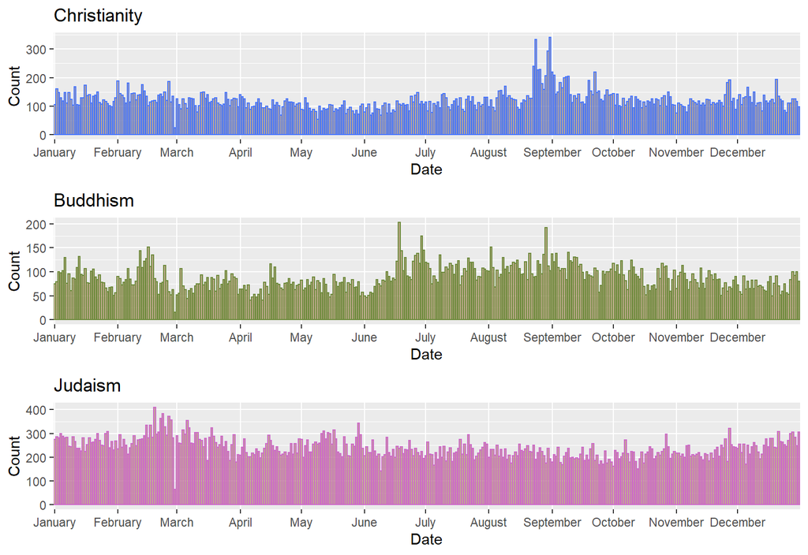

## Liczba postów na dzień tygodnia

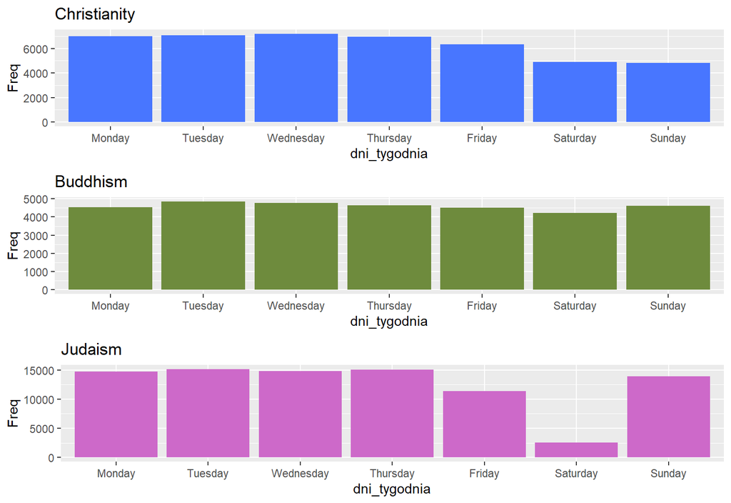

## Liczba komentarzy na dzień tygodnia

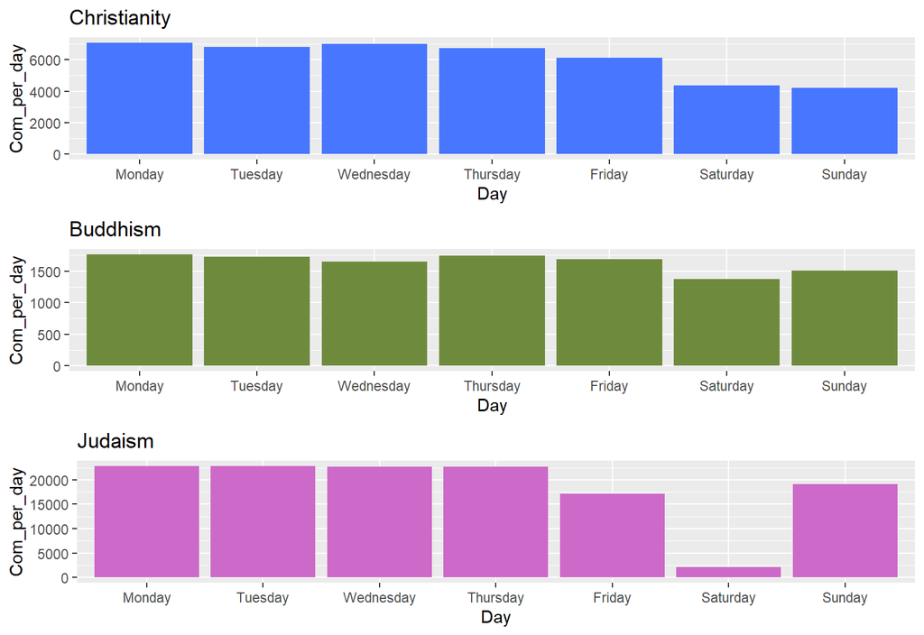

## Czas odpowiedzi

Christianity

| Monday | 115 days |
| --- | --- |
| Tuesday | 107 days |
| Wednesday | 115 days |
| Thursday | 108 days |
| Friday | 98 days |
| Saturday | 122 days |
| Sunday | 130 days |

Buddhism

| Monday | 46 days |
| --- | --- |
| Tuesday | 40 days |
| Wednesday | 45 days |
| Thursday | 65 days |
| Friday | 57 days |
| Saturday | 58 days |
| Sunday | 61 days |

Judaism

| Monday | 108 days |
| --- | --- |
| Tuesday | 118 days |
| Wednesday | 114 days |
| Thursday | 114 days |
| Friday | 121 days |
| Saturday | 205 days |
| Sunday | 108 days |

## Tagi na poszczególnych forach

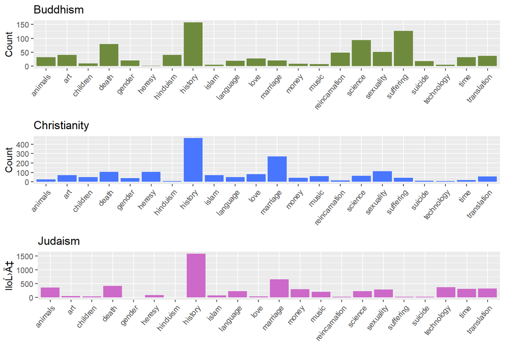

## Zamknięte i zablokowane posty

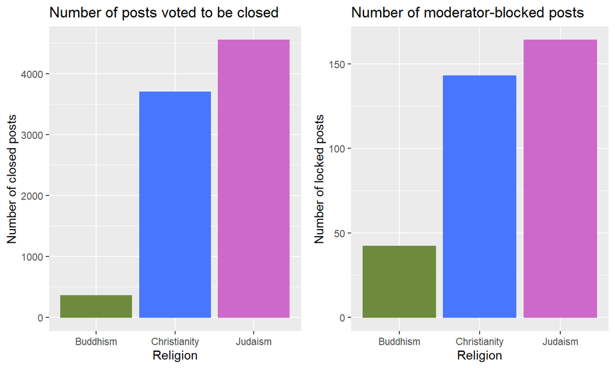

## Gęstości Grzesia (1)

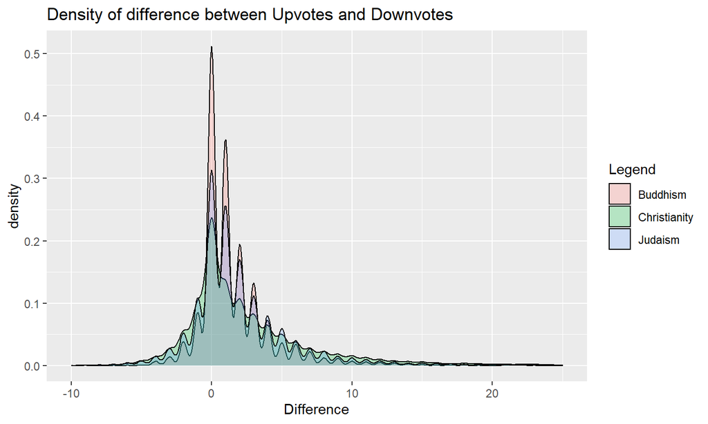

## Gęstości Grzesia (2)

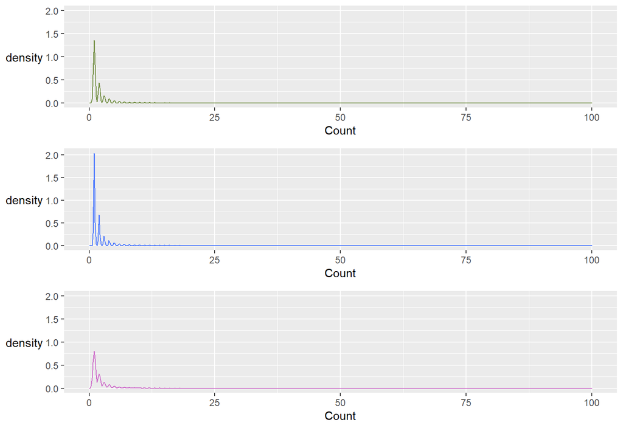

## Gęstości Grzesia (3)

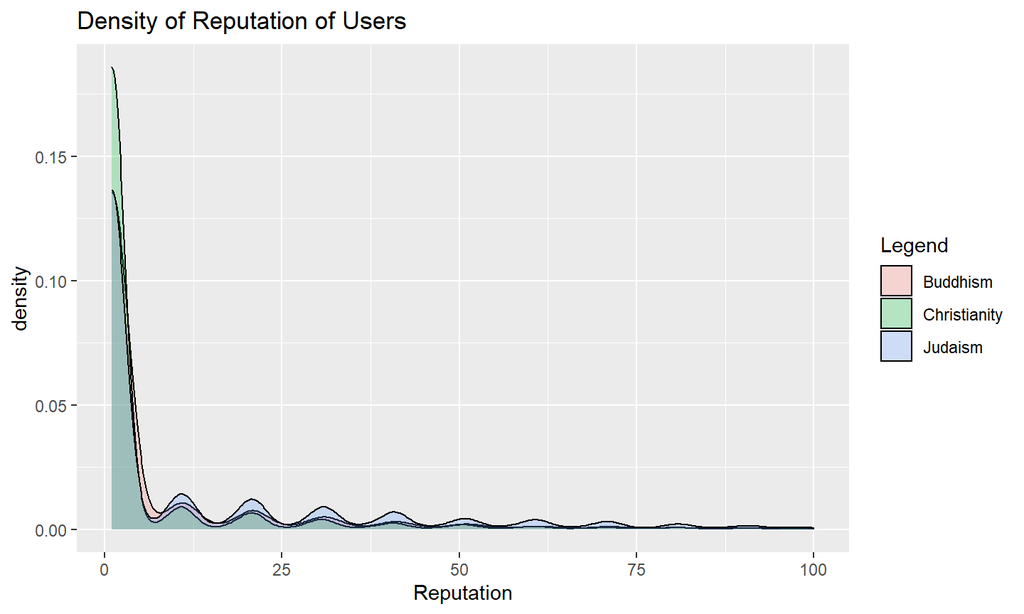

## Typy użytkowników

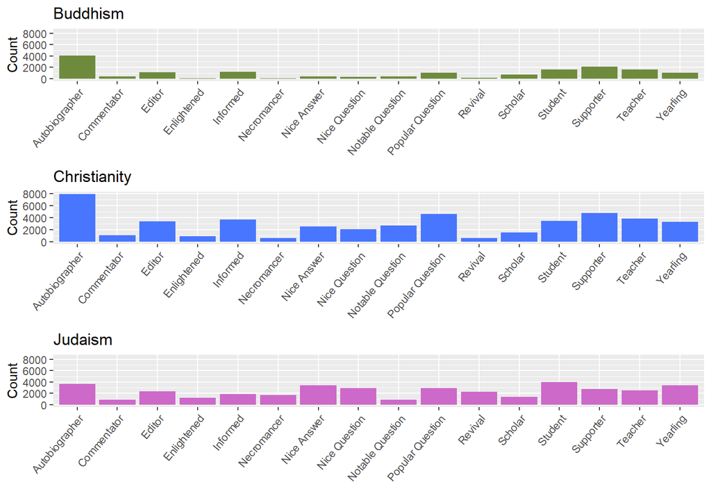

## Zależność odznak od reputacji użytkowników

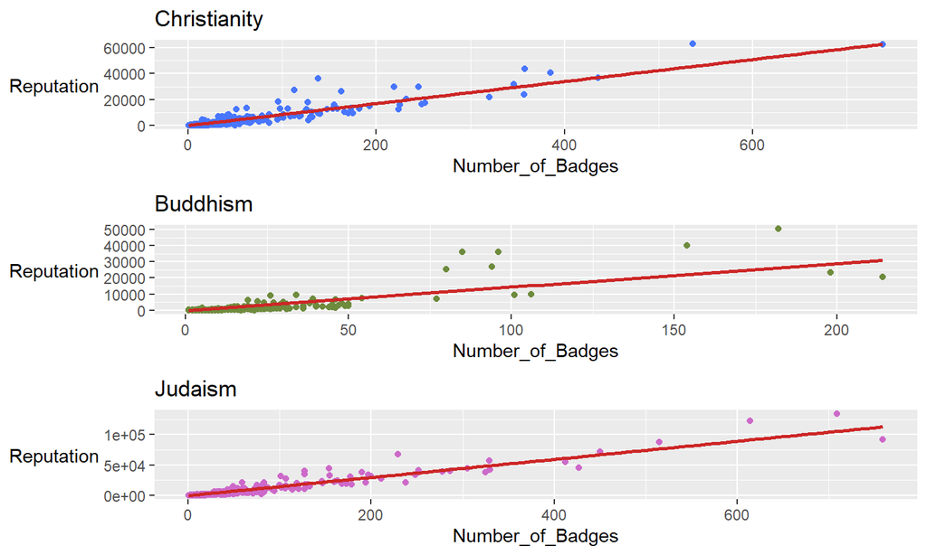

|  | Buddhism | Christianity | Judaism |
| --- | --- | --- | --- |
| Slope | 146 | 85 | 149 |

## Najwięcej postów od jednego użytkownika

| OwnerUserId | CreDate | NumberOfPosts |
| --- | --- | --- |
| 87 | 2011-03-18 | 25 |
| 17591 | 2021-02-17 | 17 |
| 87 | 2011-01-09 | 16 |
| 124 | 2010-05-03 | 15 |
| 223 | 2011-01-25 | 15 |
| 87 | 2011-01-02 | 13 |
| 87 | 2010-11-29 | 12 |
| 87 | 2011-01-26 | 11 |
| 87 | 2010-07-18 | 10 |
| 114 | 2010-04-15 | 10 |

## Pijany użytkownik forum

| Title | CreationDate |
| --- | --- |
| Megilah or Havdalah, which is done first? Why? | 2011-03-18 01:32:02 |
| Mattanos Levyonim via Jerusalem organazations | 2011-03-18 01:36:20 |
| Music on Tannis Esther | 2011-03-18 04:36:23 |
| Can you use Liquor to fulfill Ad Dlo Yoda? | 2011-03-18 19:13:20 |
| Drunken Davening | 2011-03-18 19:15:56 |
| Ad Dlo Yoda measurments | 2011-03-18 19:18:37 |
| Using Grape Juice for Ad dlo Yoda | 2011-03-18 19:20:15 |
| Non responsibility for Damages on Purim | 2011-03-18 19:22:28 |
| Parshas Zachor Sfardi versus Ashkenazi | 2011-03-18 20:03:44 |
| Zeicher vs Zecher | 2011-03-18 20:14:49 |
| Parshat Zachor - Do you need to understand or just hear | 2011-03-18 20:17:48 |
| Women and Parshas Zachor | 2011-03-18 20:19:34 |
| Masser for Machtzis Hashekel | 2011-03-18 20:20:49 |
| Meggilah Minyan | 2011-03-18 20:22:25 |
| Reading Meggilah for women | 2011-03-18 20:28:46 |
| Already read Motzeh Others | 2011-03-18 20:30:00 |
| Time for Reading the Meggilah | 2011-03-18 20:31:01 |
| Microphone for Meggilah | 2011-03-18 20:33:26 |
| May one eat before the obligatory reading/hearing of Megillas Esther? | 2011-03-18 20:35:48 |
| Check for Mattanos Levyonim | 2011-03-18 20:37:30 |
| Messenger required for Shaloch Manos? | 2011-03-18 20:39:31 |
| Multiple people using one Shalach Manos | 2011-03-18 20:41:12 |
| Nightime Seudah on Purim | 2011-03-18 20:43:15 |
| Optimal time for Meal on Purim | 2011-03-18 20:44:26 |
| Is Cross dressing allowed on purim | 2011-03-18 20:46:06 |

## Pizza

How many slices are required to make you responsible to wash on Pizza?

1. The opinion of Harav Moshe Feinstein ztâ€ťl holds two slices makes you responsible to wash.(I believe this would be the Main Psak (Halachic Ruling) for American’s)
2. Harav Shlomo Zalman Aurbach ztâ€ťl, and Harav Elyashiv say any Pizza would require one to wash and bentch (V’zos Habrocha page 230).
3. Rav Belsky Shlita Rosh Yeshiva of Torah Voddas and Posek for the Orthodox Union says  
   two slices would only be a meal if they are eaten with something else, such as a knish.While I personally ascribe to 3 each person should seek Rabbinical counsel for this and all other question.

Square otherwise known as Sicilian pizza which is made by first baking the dough and then adding the cheese is always Hamotzei the same applies to Pita-Pizza made by taking a Pita and putting cheese and Ketchup on it the Bracha also maintains it’s Hamotzie status.

The above is a summary of a recent Halachicly Speaking article available here:http://www.ladaat.net/siteimages/fl_4c1258431c6eb.pdf